# The 2008 Structural Break in the US Consumption–Income–Wealth Cointegrating Relationship

Working Paper | First break detection 2016; definitive estimate June 2026

Author

Carlos Galindo Escajeda

Status

Preliminary working paper, June 2026 — please do not cite or quote without permission

For decades before 2008, rising US household wealth reliably lifted consumer spending: in the long run, each extra dollar of net worth translated into roughly 15 cents of additional consumption. That transmission collapsed after the 2008 financial crisis. The post-2008 figure, estimated here over 72 quarters of post-crisis data, is about 1.4 cents per dollar — a 91% fall, statistically indistinguishable from zero. The income-to-spending link did not break; if anything it strengthened. There is tentative, not-yet-definitive evidence of a partial post-COVID revival, but nowhere near pre-2008 magnitudes. The policy implication is direct: monetary strategy that relies on inflating equity and house prices to stimulate spending — the wealth-effect channel — was operating through a mechanism that was severely impaired and largely dormant in aggregate data across 2008–2025. The Fed’s own research now finds the contemporaneous propensity to spend out of wealth fell roughly 20% after 2012, concentrated in high-wealth households who barely spend incremental gains, and concludes it “dampens the transmission of any policy interventions that affect household wealth” — yet the Fed’s official meeting notes as recently as March 2026 still attribute resilient spending to “gains in household wealth.” Pre-2008 magnitudes are not a defensible planning assumption, and the premise behind them is contested inside the institution that relies on them most.

This paper extends the 2016 first-detection companion (“The 2008 Structural Break in the US Consumption–Income–Wealth Cointegrating Relationship: First Detection”) to a full post-break sample, confirming the break decisively and quantifying the post-crisis relationship for the first time.

## 1. Introduction

The permanent income hypothesis (Hall, 1978) implies that consumption tracks permanent income. Lettau and Ludvigson (2001) extended this framework empirically, documenting that real consumption, real disposable income, and real net worth are cointegrated in the United States, with the cointegrating ratio predicting equity returns. The long-run consumption function implied by this relationship — with a wealth elasticity of roughly 0.15 — shaped macroeconomic policy analysis for two decades. Clarida (1991) established the aggregate consumption cointegration framework on which this literature rests; the Lettau-Ludvigson specification is its most influential implementation.

This paper asks whether that relationship survived the 2008 Global Financial Crisis. The question matters for three reasons.

**The GFC was not a standard recession.** US household net worth fell by roughly $13 trillion between 2007Q3 and 2009Q1 — approximately 20% of total household wealth. The transmission channels through which wealth historically boosted consumption — home equity withdrawal, refinancing-driven cash-out, collateral-based borrowing — were simultaneously and severely constrained. A pre-GFC calibration of the wealth elasticity carries no theoretical guarantee of post-GFC stability.

**Post-GFC micro evidence points to compression.** JPMorgan Chase Institute (2020) documents that the marginal propensity to consume out of housing wealth fell from roughly 11 cents per dollar in the 1990s to under 2 cents per dollar in 2012–2018. Cho, Morley and Singh (2024) confirm a structural break in this propensity at the end of the housing boom, driven by homeowners with low liquid wealth facing binding borrowing constraints. Post-COVID, the IMF (Devries et al., 2024) estimates the housing propensity recovered to approximately 3 cents per dollar, suggesting a possible U-shaped trajectory.

**No prior paper has formally tested for a break in the Johansen (1988, 1991) VECM specification.** Dauber and Lawrenz (2023) document structural degradation of the *cay* cointegrating ratio since roughly 2010 in the return-prediction application. Cepni (2021) finds Markov-switching in *cay* variants. Slacalek (2004) provides international evidence that consumption, income, and wealth cointegrate across OECD economies on the Lettau-Ludvigson pattern, establishing that the US relationship is not idiosyncratic. But the consumption-function interpretation — the income and wealth coefficients in the full system — has not been subjected to a formal break test with sub-sample estimates. This paper closes that gap.

We build on the 2016 companion paper (“First Detection”), which identified the break using data through 2015Q4 (Chow LR = 107.1, p < 0.001) but could not estimate the post-break relationship reliably due to the short post-break sample. This paper delivers the definitive analysis with data through 2025Q4 (72 post-break quarters), making post-crisis sub-sample estimation tractable for the first time. The full estimation machinery — specification, diagnostics, and every coefficient table — is in the Appendix; the body that follows is the interpretation. The main empirical findings concern the reorganisation of the long-run relationship (§2); the policy and institutional implications of that reorganisation, centred on what the Federal Reserve understood and when, follow in §3; and the mechanisms behind the collapse, together with the open question of whether the 2020s are opening a third regime, are taken up in §4.

## 2. The reorganisation of the long-run relationship

The paper’s central and most secure result is the reorganisation of the long-run attractor: the cointegrating relationship survived the GFC, but wealth’s role in it collapsed (β_wealth: 0.149 → 0.014, statistically zero post-GFC) while income absorbed the entire long-run anchor (β_income → 1.065, homogeneity no longer rejected). The analysis that follows traces what changed — the attractor itself, the adjustment dynamics, and the break-date evidence — at different levels of confidence. The attractor result is the most robust; the stagnation-decade decompositions are explicitly exploratory.

### The attractor moved: from wealth to income

There is still exactly one long-run relationship binding consumption, income, and wealth — in every sub-period we examine. What changed is what that relationship rests on. Before 2008, long-run consumption tracked both income (coefficient ≈ 0.89) and wealth (≈ 0.15). After 2008, the wealth coefficient falls to 0.014 — statistically zero — while the income coefficient rises to 1.07 in the post-crisis sub-sample (and to 1.035 in the full-sample estimate that blends both regimes), crossing one-for-one in both cases.

The 95% confidence intervals anchor the collapse. The Johansen pre-GFC CI for β_wealth is [0.091, 0.206]; the full-sample CI is [−0.056, 0.086]. These intervals do not overlap — a narrow gap of about 0.005 — so the long-run wealth elasticity demonstrably fell between the two regimes. The collapse is unambiguous not from this single interval comparison alone but from its convergence with the full-sample near-zero point estimate (0.015–0.044 across Johansen, DOLS, and FMOLS; see Table B6) and the recursive trace showing progressive decline from 2013. The post-2008 sub-sample CI is wide: [−0.221, 0.249]. With only 72 post-crisis quarters, a three-variable system lacks the power to distinguish small positive elasticities from zero, and the single-equation cross-checks (DOLS: 0.218; FMOLS: 0.343) are imprecise positives that do not indicate a strong channel — they indicate that the sub-sample is uninformative across methods. The collapse claim therefore rests on the full-sample estimate (robust across estimators), the recursive trace, and the disjoint pre-GFC vs full-sample CIs, not on the noisy post-2008 sub-sample point estimates. The estimator robustness is documented in Table B6: pre-GFC β_wealth runs 0.149–0.180 (all significant) across Johansen, DOLS, and FMOLS; the full-sample equivalent runs 0.015–0.044 (all insignificant); the post-GFC sub-sample ranges 0.014–0.343 with standard errors of 0.12–0.14, reflecting the sub-sample’s limited identification power rather than a strong positive signal.

Figure 1 traces the migration through expanding-window estimates. As the wealth link slides toward zero from 2013, the income link climbs through unity. Post-crisis, long-run consumption became a near-pure function of income — the textbook permanent-income result, arrived at not by design but by the wealth term dying and income absorbing the entire load.

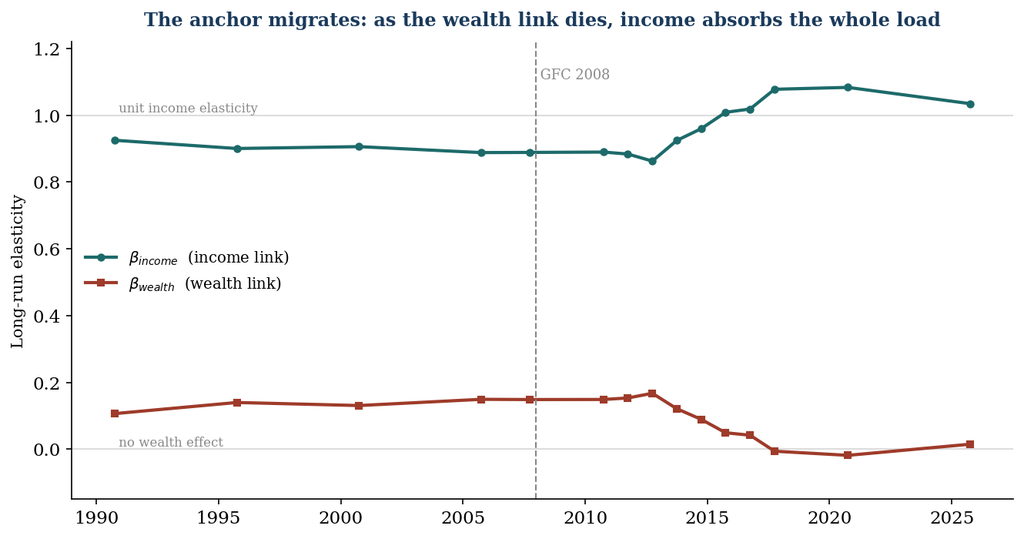

**Figure 1.** Recursive (expanding-window) long-run elasticities, 1990–2025. As the wealth link collapses to zero after 2012, the income link rises through unity — the long-run anchor migrates from wealth to income.

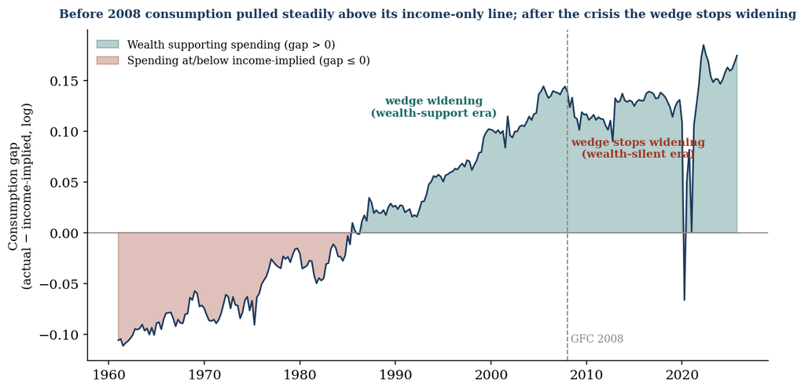

### Adjustment dynamics: who corrects, and how

This is the result most easily missed. A working wealth effect needs two things: a long-run link (does a wealth gain raise the level of consumption a household will eventually settle at?) and behavioural adjustment (does the household actually move its spending toward that new target?). The product of the two — the *effective channel* — is what converts asset prices into demand. Note that the effective channel as used here (β_wealth × |α_lrc|) is an illustrative heuristic constructed to visualise two-dimensional failure; it is not a standard object reported by VECM estimation software.

Figure 2 places the three regimes in that two-dimensional space, against curves of equal effective channel. The pre-crisis economy sits on the highest curve. Both post-crisis regimes sit lower — but they fail on *different axes*. In the 2008–2019 stagnation decade the long-run link was, if anything, stronger than ever (≈ 0.23), yet the adjustment speed collapsed to essentially zero: households’ eventual target still moved with wealth, but they stopped moving toward it. Across the full post-crisis sample the opposite leg gives way — adjustment is brisk, but the long-run link itself is gone. Either way the effective channel falls by more than half. The stagnation-decade figures rest on the exploratory sub-sample of 48 observations and should be read as illustrative rather than definitive (see Appendix D6 and the sample-caveat paragraph below).

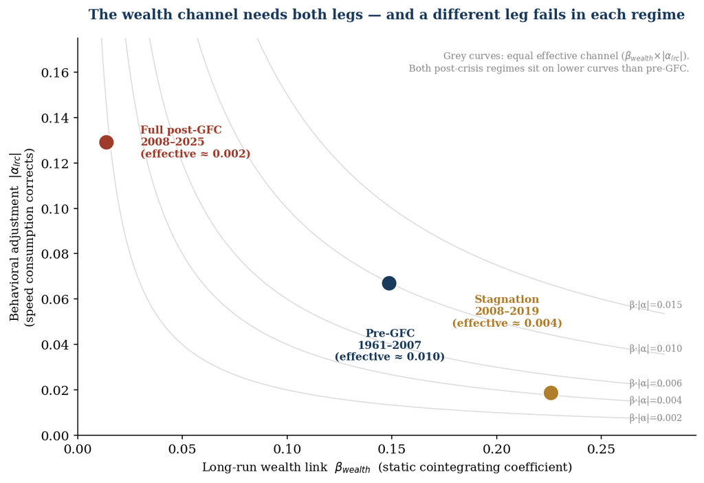

**Figure 2.** The two-axis failure map. The effective wealth channel is the product of the long-run link ($\beta_{wealth}$) and the speed consumption adjusts to it ($|\alpha_{lrc}|$). Grey curves connect points of equal effective channel. Pre-GFC sits highest; the stagnation decade fails through dead adjustment (high link, near-zero speed); the full post-crisis sample fails through a dead link (near-zero coefficient, brisk speed). The effective channel is an illustrative heuristic, not a standard VECM object. The stagnation-regime estimates rest on only 48 observations in a multi-equation system and should be read cautiously.

The most statistically supported change in system dynamics is not which variable leads and which follows, but *which variable does the error-correcting*. Weak-exogeneity likelihood-ratio tests (H₀: α_i = 0, df = 1), estimated by maximum likelihood on each sub-sample, tell a clear story. Before 2008, income adjusts (LR = 4.05, p = 0.044 — reject H₀) while consumption does not (LR = 1.48, p = 0.223 — fail to reject) and wealth does not (LR = 2.19, p = 0.139 — fail to reject): the system corrected through income. After 2008, that burden shifts: consumption adjusts (LR = 5.00, p = 0.025 — reject H₀), income falls to borderline (LR = 3.43, p = 0.064 — fail to reject at 5%), and wealth remains weakly exogenous (LR = 0.90, p = 0.342 — fail to reject). The adjustment burden shifted from income to consumption across the GFC. Wealth is weakly exogenous in both eras — its adjustment coefficient is statistically indistinguishable from zero throughout (p = 0.139 pre-GFC, p = 0.342 post-GFC). The wealth adjustment coefficient shows a sign change between the two periods (+0.194 pre-GFC, −0.065 full sample), but both estimates are statistically zero; a sign change between two insignificant estimates is not a defensible finding. What is defensible about wealth is different: it dropped out of the cointegrating vector entirely (β_wealth → 0), meaning it no longer anchors the long-run level of consumption — while remaining a statistically forcing variable that is not driven by the equilibrium gap. (Adjustment coefficients in Appendix Table B2; weak-exogeneity test statistics in Table B2, Panel B.)

The wealth effect did not simply shrink. The machinery that converts wealth into spending came apart — and in the 2010s it came apart specifically at the *behavioural* joint, while the statistical link in levels looked healthier than ever. A wealth effect can be present in the levels and dead in practice.

### Break-date evidence: real and diffuse

The formal test for a 2008 break roughly doubled in strength when ten more years of data were added — from 107 with data through 2015 to 223 through 2025. A transitory disturbance washes out as the sample grows; instead the break persists and strengthens — though, as the paragraphs below show, part of the post-2020 increase reflects pandemic-era variance rather than new information. Whatever happened around 2008 is a standing feature of the data, not a passing one.

A newly computed endogenous break-date profile (Quandt-Andrews sup-LR; the Chow LR evaluated at each candidate break date using the same VECM specification) confirms that a break is decisive across the entire search window — the Chow LR exceeds 200 at every candidate date from 2004 to 2019 (p ≈ 0 throughout). On the full sample the profile rises monotonically (2004: 201.9; 2008: 222.7; 2013: 266.5; 2019: 320.7) with no interior peak, which would superficially suggest a late or gradual break. That pattern, however, is largely an artifact of the COVID-era quarters: every post-break sub-sample in the full-sample profile contains the high-variance 2020–2022 observations, and because the Chow LR is variance-sensitive, moving the split later mechanically inflates the statistic.

The pre-COVID robustness profile (1961Q1–2019Q4, no pandemic quarters) removes that artifact and is more informative. The pre-COVID Chow LR is roughly half its full-sample value — about 103 at a 2008 break versus 223 with COVID — and the profile is non-monotonic — roughly 94–113 across 2004–2012, with a 2013 uptick to ~120 that aligns with the recursive transition — not the steep monotonic climb of the full-sample profile. Two conclusions follow. First, the break is COVID-robust: even without the pandemic quarters, parameter constancy across 2008 is rejected decisively (LR ≈ 103, df ≈ 35, p < 0.001 against a 0.1% critical value of ≈ 66.6). Second, no single date is cleanly preferred — the pre-COVID profile shows no monotonic post-2008 climb across the mid-2000s to early-2010s, consistent with the recursive evidence in Table B4 (β_wealth stable through 2012, then collapsing through 2017). The honest reading is therefore that a structural change anchored to the GFC is real and survives the removal of COVID, but its precise dating is diffuse and the headline full-sample statistic (223) is inflated by pandemic-era variance; the cleaner pre-COVID magnitude is roughly 103. Accordingly, “the 2008 … break” in this paper’s title denotes a GFC-anchored, COVID-robust regime change — not a knife-edge date. (Results from all three break tests are available from the authors upon request.)

The post-GFC sub-sample is 72 quarters — workable but tight for a multi-equation system. The stagnation sub-sample (2008Q1–2019Q4, n = 48) is tighter still. The COVID impulse dummy absorbs the 2020Q1–Q2 level shift but does not address the elevated innovation variance during the COVID episode; as a result, all post-GFC adjustment coefficients and sub-sample decompositions carry more uncertainty than the pre-GFC estimates, and the stagnation-decade figures should be treated as exploratory. The fuller discussion of these limitations is in Appendix D.

## 3. What the Fed understood — and when

This section documents a contradiction internal to a single institution. The Federal Reserve’s own staff research now finds the long-run wealth-to-consumption channel severely impaired; the Fed’s own policy record continues to credit rising household wealth as a support for consumer spending. Both the evidence and the rhetoric originate inside the Fed, and they no longer agree — and the gap is fully documented in the Fed’s own papers and minutes, not inferred from outside. What follows traces that gap from the channel’s operationalisation to its quiet empirical disavowal.

The Federal Reserve did not merely tolerate the wealth channel as a side-effect of policy; it operationalised it. When the Fed launched its second round of large-scale asset purchases in 2010, Chairman Bernanke stated the mechanism in plain terms: “Higher stock prices will boost consumer wealth and help increase confidence, which can also spur spending. Increased spending will lead to higher incomes and profits that, in a virtuous circle, will further support economic expansion” (Bernanke, 2010). Three years later, with the policy still running, Governor Powell confirmed the same logic: “Lower rates also support the prices of housing and financial assets such as stocks and bonds. Higher asset prices increase wealth and, with a lag, induce higher spending” — though he added, honestly, that the channels “may not be working perfectly” and were “mixed, but positive on balance” (Powell, 2013). The wealth effect was not an implicit assumption inside a black-box model; it was the stated transmission mechanism of the Fed’s signature post-crisis instrument.

Over the following decade the Fed’s own research systematically dismantled that premise. The Federal Reserve Board’s 2025 FEDS Note on wealth heterogeneity finds that the marginal propensity to consume out of wealth declined from 3.3 cents per dollar before 2012 to 2.7 cents after — a fall of roughly 20%. More damaging than the aggregate decline is its distribution: top-income-quintile wealth fluctuations imply only about 0.8 cents of spending per dollar, versus roughly 7.5 cents for the bottom 80%. Because post-crisis asset gains accrued overwhelmingly to the top quintile, the aggregate effect collapsed mechanically. The note states directly that the declining propensity “dampens the transmission of any policy interventions that affect household wealth” (Federal Reserve Board, 2025). This is the Fed’s own researchers concluding, in measured language, that the channel QE was designed to exploit had shrunk to a fraction of its pre-crisis magnitude.

What makes this a live institutional risk rather than a settled research debate is that the Fed’s operating narrative has not caught up with its research. The minutes of the March 2026 FOMC meeting attribute consumer resilience to “gains in household wealth” — the same framing that animated 2010 policy, now applied to an economy the Fed’s own researchers describe as significantly less responsive to wealth shocks (Federal Open Market Committee, 2026). This is not a failure of communication between outside critics and a defensive institution; it is a research–rhetoric gap inside the same institution. Policy explained and calibrated on a premise the institution’s own economists have undercut represents an institutional narrative lag and a transmission-calibration risk, not merely a technical footnote.

The post-COVID episode provides a natural test of the disconnection — and the data are consistent with it. The Federal Reserve Bank of San Francisco estimates that equity-driven excess household wealth peaked at roughly $13 trillion in late 2021 and fell back to approximately zero by late 2022, an extraordinary two-year round-trip (Federal Reserve Bank of San Francisco, 2024). Consumer spending did not follow: it held up through the deflation of the wealth surge and into the period of near-zero excess wealth. The Fed’s own reading of that resilience attributes it to an excess-savings cushion built from fiscal transfers — an income stock, not a wealth effect. Wealth surged and collapsed; spending barely moved. That is consistent with the structural reorganisation this paper identifies: the long-run anchor of consumption has shifted to income, and wealth’s role in the long-run relationship is statistically indistinguishable from zero across the full post-2008 sample.

The FEDS Note’s roughly 20% contemporaneous decline in the spending propensity is milder than this paper’s estimated 91% long-run collapse — but these are different objects, measuring different things. A contemporaneous marginal propensity to consume captures a quarter-by-quarter spending response to a wealth shock; a cointegrating coefficient captures where the long-run level of consumption settles relative to the long-run level of wealth. The error-correction speed — how fast actual spending closes the gap to its long-run target — is a third, separate dimension. The two results are not in tension; they are congruent in direction and different in degree, measuring complementary aspects of the same broken mechanism. This paper’s structural and long-run reading is consistent with, and stronger than, the contemporaneous evidence the Fed’s own researchers have produced.

The practical implication is stronger than “the wealth lever is weaker.” The long-run link between wealth and consumption is statistically indistinguishable from zero in post-2008 data — the lever is operating well below its pre-crisis magnitude. A central bank that lifts equity and house prices to stimulate spending is operating through a channel that no longer anchors the long-run level of consumption; the wealth gains accumulate in portfolios rather than converting to spending. This resolves a decade-long puzzle: the asset-price reflation of the 2010s inflated portfolios without lifting consumption; the income transfers of 2020–21 moved spending immediately. The model says exactly that — the income anchor strengthened to one-for-one over the same period the wealth anchor died. For anyone calibrating the transmission of monetary policy, a pre-2008 wealth elasticity of fifteen cents is not a conservative assumption — it is misplaced confidence in a channel operating well below its historical magnitude.

There is a financial-stability consideration that follows from the same evidence. Asset-price stimulus that does not feed spending does not merely do nothing — it accumulates as portfolio gains disconnected from consumption, raising the question of what conditions would eventually bring them back into alignment. The cost of leaning on a largely dormant channel is not just a demand disappointment; it is a stock of asset-price appreciation that has grown beyond what the consumption relationship can absorb.

**In plain terms.** For years the Federal Reserve tried to support consumer spending by pushing up stock and house prices, based on the belief that richer households spend more. Its own researchers have since shown that this link is severely impaired: the extra wealth mostly flows to high-income households who do not meaningfully increase their spending when their portfolios rise. The figures are not contested — they come from a Federal Reserve staff paper. But the Fed’s official meeting notes, as recently as early 2026, continue to describe rising household wealth as a key support for spending. That gap matters practically: if the channel is operating well below its pre-crisis magnitude but policymakers still explain and calibrate their decisions through it, they may lift asset prices far above what the economy needs — creating expensive portfolios without proportionally more spending, and an overhang that eventually has to unwind.

## 4. Mechanisms and the open question

Put the findings together and the familiar headline — “the wealth effect collapsed” — undersells what happened. The relationship did not vanish; it reorganised. Long-run consumption retreated to a pure income anchor — the attractor moved, not just its magnitude. The behavioural feedback that turned wealth gains into spending fell silent — even in the years when the level link looked strongest. And the burden of error-correction shifted from income (which adjusted pre-GFC) to consumption (which adjusts post-GFC), while wealth remained a forcing variable throughout — statistically exogenous in both eras. The cause of US consumption is now income; wealth has dropped out of the long-run anchor while remaining a variable the system does not correct toward.

The data show a permanent structural break; they do not by themselves identify the causal mechanism. Four reinforcing causes are consistent with the evidence, and they all point the same way: the marginal dollar of post-crisis wealth gain accrued where it would not be spent. Home equity withdrawal — the primary pre-crisis conduit documented by JPMorgan Chase Institute (2020), which fell from 11 cents per dollar in the 1990s to under 2 cents post-GFC — was shut by falling prices and tighter credit; the channel required rising prices and available collateral, and both conditions reversed simultaneously after 2008. Balance-sheet repair absorbed the subsequent recovery in asset values into debt reduction rather than spending: Mian, Rao and Sufi (2013) show the consumption decline was driven by net worth destruction concentrated in high-leverage housing markets, and rising asset values post-2010 went largely to repairing those balance sheets rather than expanding spending. Wealth concentration compounded both effects — post-GFC equity market recovery accrued disproportionately to high-wealth households with near-zero marginal propensities to consume (Federal Reserve Board, 2025; Propst, 2025), so the aggregate elasticity fell mechanically as gains concentrated away from high-propensity spenders. Finally, the degradation of the *cay* cointegrating ratio documented by Dauber and Lawrenz (2023) since approximately 2010 reflects the same underlying process from the return-prediction side: consumption and wealth diverged from their historical long-run relationship, and the ratio lost its predictive content as the relationship reorganised. The mechanisms are detailed further in Appendix C.

Three of these four mechanisms have a candidate unifying frame. Mian, Straub and Sufi (2021) formalise *indebted demand*: rising inequality and financial liberalisation channel the savings of high-income households — whose saving rates rise with permanent income — into the debts of other households; once the debt is in place, servicing it transfers income from high- to low-propensity spenders, depressing aggregate demand and the natural rate of interest, and policy that stimulates demand by encouraging further borrowing buys today’s spending at the cost of tomorrow’s debt drag. Read through that frame, the home-equity shutdown, the balance-sheet repair, and the concentration of gains are successive phases of one credit cycle rather than unrelated headwinds — though the model itself does not generate all three, so the unification is interpretive rather than structural. The cross-sectional pattern the Fed’s own research later documented (Federal Reserve Board, 2025; §3) — wealth gains accruing to households that barely spend them — is consistent with the framework’s heterogeneous-saving mechanism.

Two qualifications keep the fit honest. First, the mapping to this paper’s central estimate is indirect: a cointegrating coefficient is a property of the long-run aggregate relationship, not a marginal propensity to consume. The theory’s distributional mechanism — aggregate wealth increasingly held where it no longer anchors aggregate consumption — is consistent with an attenuated aggregate wealth coefficient; nothing in the model singles out zero. Second, the timing narrows which version of the story survives. Household debt-service burdens fell from their 2007 peak (13.2% of disposable income) to below their pre-crisis historical range by the mid-2010s and reached a record low in early 2021 (Federal Reserve Board, 2026; dates refer to the underlying observations) — yet the structural transition the data locate in the early-to-mid 2010s (§2) deepens over those same years, and β_wealth remains statistically indistinguishable from zero through 2025. That weighs against accounts in which the aggregate payment burden alone suppressed the channel. It does not dispose of every transient-overhang variant: the debt-service ratio is a flow measure, pushed down by low interest rates and refinancing as well as by repayment, and it can normalise while debt stocks, underwater collateral, or impaired credit access still bind for precisely the high-propensity households that once carried the wealth effect — and the diffuse dating of the break overlaps the deleveraging years, so the temporal ordering is not sharp. What the timing leaves standing is the persistent-regime reading of indebted demand — on which the binding object is the stock and distribution of debt rather than the payment flow — alongside the narrower concentration-plus-credit-technology account. The aggregate three-variable system cannot identify which latent mechanism produced the break; a system augmented with household leverage is the natural next step — informative, though not by itself decisive, since leverage responds to the same forces it would be asked to explain — and requires data beyond the series used here.

Recent evidence supports a U-shaped trajectory for the wealth effect: high pre-GFC, near-zero across 2010–2019, and partially recovering post-2020 (IMF WP 2024/128; Cho, Morley and Singh, 2024; Federal Reserve Bank of San Francisco, 2024). The aggregate post-2008 estimate of β_wealth = 0.014 is a time-average over these sub-regimes, blending the inactive stagnation decade with whatever the 2020s are doing. The income channel — β_income converging toward unity — remains intact throughout.

What the data cannot yet settle is whether the 2020s reopen the wealth channel. Independent micro evidence points to a partial post-COVID revival in the housing wealth effect, and the aggregate post-crisis estimate blends a demonstrably dead 2010s with a possibly-reviving 2020s. Twenty-four post-2020 quarters cannot separate the two. If a third regime is forming, it will announce itself first through the adjustment coefficient — the behavioural joint that failed in the 2010s — coming back to life. That is the number to watch.

The empirical question raised when this work began — whether the pre-2008 consumption–wealth relationship survived the crisis — is now settled. It did not. What replaced it is not a smaller version of the same relationship but a structurally different one, in which income does the long-run anchoring work, wealth has dropped out of that anchor while remaining statistically exogenous, and the adjustment burden has shifted to consumption. Whether the post-COVID partial revival in micro-estimated housing wealth effects represents a genuine third regime or a transitory fluctuation is precisely the open question the next cycle of data will resolve. A channel calibrated on pre-2008 wealth elasticities is calibrated on a structural regime that no longer exists in the data.

# Appendix

## Appendix A. Data and specification

**Series.** All data from FRED (Federal Reserve Bank of St. Louis):

| Variable | FRED code | Units |
| --- | --- | --- |
| Real consumption | PCECC96 | bn chained 2017$, SAAR |
| Real disposable income | DPIC96 | bn chained 2017$, SAAR |
| Real net worth | TNWBSHNO / (DPI/DPIC96) | bn chained 2017$ |

Log levels: lrc, lrdy, lrnw. Sample: 1961Q1–2025Q4 (n = 260).

**Net worth note.** The original Lettau-Ludvigson (2001) series (HNONWRQ027S) was discontinued in 2017Q4 and replaced by TNWBSHNO from the same Federal Reserve Z.1 source. The 2023 BEA Comprehensive Update shifted the reference year from 2009$ to 2017$, adding a constant to log levels absorbed by the cointegrating constant; the slope (beta) and adjustment (alpha) coefficients are unaffected.

**COVID impulse dummy.** A dummy equal to 1 in 2020Q1–2020Q2 and 0 elsewhere enters the short-run equations only. The 2020Q2 personal saving rate reached 33.7% — a fiscal-transfer artifact, not a behavioral shift in the long-run consumption function. Including a dummy absorbs the outlier residual while retaining the observations, following Lenza and Primiceri (2020) for COVID treatment in VARs.

**Specification.** Johansen (1988, 1991) VECM, Case 3 (unrestricted constant in the cointegrating relation), rank r = 1, 3 lagged first differences. Three estimation samples:

| Sample | Period | n |
| --- | --- | --- |
| Pre-GFC | 1961Q1–2007Q4 | 188 |
| Post-GFC | 2008Q1–2025Q4 | 72 (COVID dummy active) |
| Full | 1961Q1–2025Q4 | 260 |

## Appendix B. Full estimation results

**Rank diagnostics.** Johansen rank tests confirm r = 1 in all three samples. The trace test rejects r = 0 decisively in each; neither trace nor max-eigenvalue tests reject r ≤ 1. The max-eigenvalue test is borderline (p ≈ 0.049) in the pre-GFC sub-sample, reflecting a weak but present cointegrating relationship consistent with the slow pre-GFC error-correction speed. Rank confirmation in the post-GFC sub-sample (n = 72) is stronger, consistent with the larger post-GFC adjustment speed providing more decisive rank identification.

**Table B1. Long-run cointegrating vector** (normalized on lrc, Case 3, r = 1):

| Parameter | Pre-GFC (1961–2007) | Full sample (1961–2025) | Post-GFC (2008–2025) |
| --- | --- | --- | --- |
| beta_income | 0.889 (SE = 0.033) | 1.035 (SE = 0.044) | 1.065 (SE = 0.219) |
| beta_wealth | **0.149** (SE = 0.029, t = 5.1) | **0.015** (SE = 0.036, t = 0.4) | **0.014** (SE = 0.120, t ≈ 0.1) |

The wealth elasticity collapsed from 0.149 to 0.014 — a 91% reduction; in the post-GFC sub-sample it is indistinguishable from zero. The income elasticity moved from 0.889 to 1.065, crossing unity: homogeneity (beta_income = 1) was rejected at the 10% level pre-GFC (p ≈ 0.081) and is not rejected in the full sample (p = 0.486). The pre-GFC income coefficient below unity is consistent with Campbell and Mankiw (1989, 1991), who document that a fraction of income follows current rather than permanent income — a rule-of-thumb household share that reduces the aggregate income elasticity below one. The post-GFC convergence toward unity suggests this friction weakened as the wealth channel shut down.

**Table B2. Speed of adjustment (alpha):**

**Panel A. Adjustment coefficients (α):**

| Parameter | Pre-GFC | Full sample | Post-GFC |
| --- | --- | --- | --- |
| alpha_lrc (consumption) | −0.067 (t ≈ −1.5) | −0.056 (t = −3.09) | −0.129 |
| alpha_lrdy (income) | +0.166 (t = 2.95) | +0.158 (t = 5.72) | — (not reported) |
| alpha_lrnw (wealth) | +0.194 (t = 1.66) | −0.065 (t = −1.35) | — (not reported) |

**Panel B. Weak-exogeneity likelihood-ratio tests (H₀: α_i = 0; single restriction; df = 1):**

*Estimated by maximum likelihood on each sub-sample.*

| Variable | Pre-GFC LR | Pre-GFC p | Pre-GFC verdict | Post-GFC LR | Post-GFC p | Post-GFC verdict |
| --- | --- | --- | --- | --- | --- | --- |
| Consumption (α_lrc) | 1.48 | 0.223 | Fail to reject — weakly exogenous | 5.00 | 0.025 | **Reject** — adjusts |
| Income (α_lrdy) | 4.05 | 0.044 | **Reject** — adjusts | 3.43 | 0.064 | Fail to reject at 5% — borderline |
| Wealth (α_lrnw) | 2.19 | 0.139 | Fail to reject — weakly exogenous | 0.90 | 0.342 | Fail to reject — weakly exogenous |

*Note: the post-GFC consumption-adjustment result is statistically significant (p = 0.025) — the primary supported change in adjustment dynamics. Wealth is weakly exogenous in both eras (p = 0.139 pre-GFC, p = 0.342 post-GFC); the sign change in its point-estimate adjustment coefficient (+0.194 → −0.065) is between two statistically zero estimates and is not a defensible finding. Income’s adjustment role weakens across the GFC (p = 0.044 → 0.064), falling below the 5% threshold in the post-GFC sample.*

Consumption corrects faster post-GFC (alpha_lrc strengthens from −0.067, insignificant, to −0.129, and the weak-exogeneity test is rejected at p = 0.025). Wealth’s adjustment point estimate reverses sign — positive pre-GFC (a bull-market signature), negative in the full-sample column — but neither estimate is statistically significant; wealth is weakly exogenous throughout.

*Methods note: the weak-exogeneity LR tests (Panel B above) and the endogenous break-date profile (Quandt-Andrews sup-LR sweep) were estimated on the same VECM specification used throughout. Results are available from the authors upon request.*

**Table B3. Chow LR test at 2008Q1:**

|  | Value |
| --- | --- |
| Log-likelihood, full sample (constrained) | 2438.937 |
| Log-likelihood, pre-GFC sub-sample | 1893.303 |
| Log-likelihood, post-GFC sub-sample | 656.997 |
| **LR = 2 × (pre + post − full)** | **222.725** |
| Degrees of freedom (approximate) | ~35 |
| p-value | **< 0.001** |

**Table B4. Recursive beta_wealth** (expanding window from 1961Q1 to each endpoint):

| Window end | n | beta_wealth | SE | t |
| --- | --- | --- | --- | --- |
| 1990Q4 | 120 | 0.107 | 0.076 | 1.4 |
| 2000Q4 | 160 | 0.131 | 0.044 | 3.0 |
| **2007Q4** | **188** | **0.149** | **0.029** | **5.1** |
| 2010Q4 | 200 | 0.149 | 0.028 | 5.3 |
| 2012Q4 | 208 | 0.167 | 0.032 | 5.3 |
| 2013Q4 | 212 | 0.121 | 0.033 | 3.6 |
| 2014Q4 | 216 | 0.089 | 0.038 | 2.3 |
| **2015Q4** | **220** | **0.049** | **0.047** | **1.0** |
| 2020Q4 | 240 | −0.018 | 0.054 | −0.3 |
| **2025Q4** | **260** | **0.015** | **0.036** | **0.4** |

**Table B5. Exploratory: stagnation sub-sample 2008Q1–2019Q4** (n = 48, no COVID dummy).

| Parameter | Stagnation (2008–2019) | Full post-GFC (2008–2025) |
| --- | --- | --- |
| beta_income | 0.518 (SE = 0.044) | 1.065 (SE = 0.219) |
| beta_wealth | 0.226 (SE = 0.022, t ≈ 10) | 0.014 (SE = 0.120, t ≈ 0.1) |
| alpha_lrc | −0.019 (SE = 0.127, t ≈ −0.15) | −0.129 |

The stagnation period produces the result behind Figure 2: beta_wealth = 0.226 (high and precisely estimated statically) alongside alpha_lrc = −0.019 (statistically zero). The static cointegrating relationship is present in levels, but consumption does not dynamically respond to deviations from it. The effective wealth channel requires both a nonzero link and nonzero adjustment; in the stagnation decade the adjustment mechanism was effectively inactive (beta × |alpha| ≈ 0.004, versus ≈ 0.010 pre-GFC). The channel broke not through a collapse in the static long-run relationship but through a collapse in the behavioral feedback. The post-COVID partial recovery (2020–2025) cannot be separately estimated (n = 24); the full 2008–2025 aggregate of 0.014 blends the inactive stagnation decade with a possible post-COVID revival.

**Table B6. Estimator robustness: long-run wealth elasticity across Johansen, DOLS, FMOLS.**

| Sample | Johansen β_wealth | DOLS β_wealth | FMOLS β_wealth |
| --- | --- | --- | --- |
| Pre-GFC (1961–2007) | 0.149 (SE 0.029) | 0.180 (SE 0.020) | 0.178 (SE 0.023) |
| Full (1961–2025) | 0.015 (SE 0.036) | 0.044 (SE 0.034) | 0.026 (SE 0.048) |
| Post-GFC sub-sample (2008–2025) | 0.014 (SE 0.120) | 0.218 (SE 0.138) | 0.343 (SE 0.126) |

*β_income for reference: pre-GFC 0.889/0.852/0.851; full sample 1.035/0.984/1.006; post-GFC 1.065/0.564/0.341 (Johansen/DOLS/FMOLS).*

*DOLS (trend = const, 2 leads/2 lags) and FMOLS (Andrews bandwidth), each a single-equation maximum-likelihood cointegrating estimator. The cross-checks omit the COVID impulse dummy (the cointegrating regressors must be I(1)). The full-sample near-zero estimate is robust across all three estimators; the post-2008 sub-sample is imprecise across methods (SEs 0.12–0.14), consistent with its limited power. Results are available from the authors upon request.*

## Appendix C. Mechanisms

The data show a permanent structural break; they do not by themselves identify the causal mechanism. Four reinforcing mechanisms are consistent with the evidence.

**Home equity access collapsed.** JPMorgan Chase Institute (2020) documents the housing consumption propensity falling from 11c/$ to under 2c/$ post-GFC. The primary pre-GFC channel was home equity withdrawal, which required rising prices and available credit; both conditions reversed after 2008.

**Balance-sheet contraction.** Mian, Rao and Sufi (2013) show the consumption decline was driven by net worth destruction concentrated in high-leverage housing markets. Rising asset values post-2010 were largely absorbed by debt reduction, not spent. Wealth-to-consumption transmission requires households to be balance-sheet solvent and collateral-constrained in the upward direction; post-GFC households were neither.

**Wealth concentration.** Post-GFC equity market recovery accrued disproportionately to high-wealth households with near-zero marginal propensities to consume (Federal Reserve, 2025). The aggregate wealth elasticity falls mechanically as wealth gains concentrate away from high-propensity households. Propst (2025) confirms this pattern in both the US and euro area.

**cay degradation.** Dauber and Lawrenz (2023) document that the predictive power of the *cay* ratio for equity returns has decayed since approximately 2010. The consumption-function interpretation is the same underlying process: the cointegrating relationship weakened as wealth diverged from its historical relationship with consumption and income.

**Unifying frame: indebted demand.** Mian, Straub and Sufi (2021) supply a common interpretive frame for the first three mechanisms: inequality and financial liberalisation build household debt whose service transfers income from high- to low-propensity spenders, depressing demand and the natural rate of interest. Two cautions on the fit: a cointegrating β is not an MPC — the theory’s distributional mechanism is consistent with attenuation of the aggregate coefficient, and nothing in it singles out zero; and the debt-service timing (burdens back below their pre-crisis range by the mid-2010s; Federal Reserve Board, 2026) weighs against payment-burden-only overhang accounts but cannot separate the persistent-regime version of the theory — a stock-of-debt mechanism — from the narrower concentration story. See §4.

Recent evidence (IMF WP 2024/128; Cho, Morley and Singh, 2024; SF Fed, 2024) supports a U-shaped trajectory: high pre-GFC, near-zero 2010–2019, partially recovering 2020–2025. Our aggregate post-2008 estimate of 0.014 is a time-average over these sub-regimes. The income channel — beta_income converging toward unity — remains intact throughout.

## Appendix D. Robustness, caveats, and scope

**D1. Near-singular post-GFC sub-sample (n = 72).** With approximately 10 free parameters per equation and n = 72, the ratio of observations to parameters is roughly 7:1 — workable but tight. Standard errors on the post-2008 beta and alpha are substantially larger than in the pre-GFC sub-sample. The qualitative finding (near-zero beta_wealth) is robust; the point estimate of 0.014 should not be over-interpreted.

**D2. COVID dummy is an approximation.** A 0/1 impulse dummy absorbs the 2020Q1–Q2 level shift but does not address the elevated innovation variance during the COVID episode. Lenza and Primiceri (2020) recommend time-varying variance scaling; the dummy is a tractable approximation.

**D4. Rudd-Whelan measurement.** Net worth is not the budget-constraint-consistent total wealth (Rudd and Whelan, 2002). All results are empirical associations on observable proxies.

**D5. Three-regime heterogeneity.** The 2008–2025 post-GFC sub-sample is not homogeneous (see Table B5). The aggregate beta_wealth = 0.014 blends the stagnation decade (inactive adjustment channel) with the post-COVID partial recovery. The 2020–2025 sub-sample (n = 24) is too small for standalone estimation.

**D6. Stagnation sub-sample instability (exploratory).** The 2008–2019 exploratory sub-sample (n = 48) shows an anomalous beta_income = 0.518 alongside a near-zero alpha_lrc. With n = 48 and extreme wealth volatility, the Johansen MLE may be calibrating to the specific sample path rather than the structural long-run relationship. These results carry more uncertainty than the primary estimates.

## Appendix E. Data and replication

Data are from FRED (Federal Reserve Bank of St. Louis). Series: PCECC96, DPIC96, TNWBSHNO. Sample: 1961Q1–2025Q4. Estimation: Johansen (1988, 1991) maximum-likelihood VECM. Data and replication code are available from the authors upon request. Verbatim Federal Reserve quotations (Bernanke, 2010; Powell, 2013; Federal Reserve Board, 2025; Federal Open Market Committee, 2026) and their primary-source URLs are documented in the authors’ research notes, available on request.

## References

- Bernanke, B.S. (2010). “What the Fed Did and Why: Supporting the Recovery and Sustaining Price Stability.” *Washington Post*, November 4.
- Campbell, J.Y. & Mankiw, N.G. (1989). “Consumption, Income, and Interest Rates.” *NBER Macroeconomics Annual* 4:185–216.
- Campbell, J.Y. & Mankiw, N.G. (1991). “The Response of Consumption to Income.” *Review of Economic Studies* 58(4):723–757.
- Cepni, O. (2021). “Time-varying cay with Markov switching.” *International Review of Finance*.
- Cho, Y., Morley, J. & Singh, A. (2024). “Did marginal propensities to consume change with the housing boom and bust?” *Journal of Applied Econometrics* 39(1):174–199.
- Clarida, R.H. (1991). “Cointegration, Aggregate Consumption, and the Demand for Imports.” *American Economic Review* 81(3):298–315.
- Dauber, M. & Lawrenz, J. (2023). “The Decay of cay.” *Review of Finance* / SSRN 4516252.
- Devries, P. et al. (2024). “Drivers of Post-COVID Private Consumption in the United States.” *IMF Working Paper* 2024/128.
- Federal Reserve Bank of San Francisco (2024). “The Rise and Fall of Pandemic Excess Wealth.” *FRBSF Economic Letter* 2024-06.
- Federal Reserve Board (2025). “Wealth Heterogeneity and Consumer Spending.” FEDS Note.
- Federal Reserve Board (2026). Household Debt Service and Financial Obligations Ratios. Statistical release, March 2026.
- Federal Open Market Committee (2026). Minutes of the March 17–18, 2026 meeting. Federal Reserve Board.
- Gregory, A.W. & Hansen, B.E. (1996). “Residual-based tests for cointegration in models with regime shifts.” *Journal of Econometrics* 70(1):99–126.
- Hall, R.E. (1978). “Stochastic Implications of the Life Cycle–Permanent Income Hypothesis.” *Journal of Political Economy* 86(6):971–987.
- Hansen, B.E. & Johansen, S. (1999). “Some Tests for Parameter Constancy in Cointegrated VAR-Models.” *Econometric Journal* 2(2):306–333.
- Johansen, S. (1988). “Statistical Analysis of Cointegration Vectors.” *Journal of Economic Dynamics and Control* 12(2–3):231–254.
- Johansen, S. (1991). “Estimation and Hypothesis Testing of Cointegration Vectors in Gaussian Vector Autoregressive Models.” *Econometrica* 59(6):1551–1580.
- Johansen, S., Mosconi, R. & Nielsen, B. (2000). “Cointegration analysis in the presence of structural breaks in the deterministic trend.” *Econometric Journal* 3(2):216–249.
- JPMorgan Chase Institute (2020). “The Housing Wealth Effect in the Post-Great Recession Period.”
- Lenza, M. & Primiceri, G.E. (2020). “How to Estimate a VAR after March 2020.” *ECB Working Paper* 2461.
- Lettau, M. & Ludvigson, S. (2001). “Consumption, Aggregate Wealth, and Expected Stock Returns.” *Journal of Finance* 56(3):815–849.
- Mian, A., Rao, K. & Sufi, A. (2013). “Household Balance Sheets, Consumption, and the Economic Slump.” *Quarterly Journal of Economics* 128(4):1687–1726.
- Mian, A., Straub, L. & Sufi, A. (2021). “Indebted Demand.” *Quarterly Journal of Economics* 136(4):2243–2307.
- Powell, J.H. (2013). “Thoughts on Unconventional Monetary Policy.” Remarks, Federal Reserve Board, June 27.
- Propst, F. (2025). “Marginal Propensity to Consume Out of Wealth.” *Review of Income and Wealth* 71.
- Rudd, J. & Whelan, K. (2002). “A Note on the Cointegration of Consumption, Income, and Wealth.” *Federal Reserve Board FEDS* 2002-53.
- Slacalek, J. (2004). “International Evidence on Cointegration Between Consumption, Income, and Wealth.” *DIW Discussion Paper* 414.